[output not shown]

## Chargement des packages et des données

```r
library(tidyverse)
```

```r
plastic_waste <- read_csv("data/plastic-waste.csv")
```

Commençons par filtrer les données pour retirer le point représenté par Trinité et Tobago (TTO) qui est un outlier.

```r
plastic_waste <- plastic_waste %>%
  filter(plastic_waste_per_cap < 3.5)
```

## Exercices

### Exercise 1

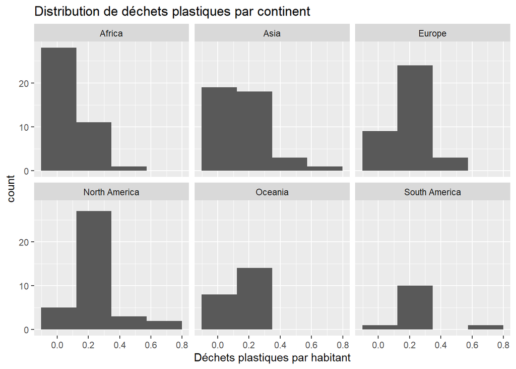

```r
ggplot(plastic_waste, aes(x = plastic_waste_per_cap)) +
  geom_histogram(bins = 4) +
         facet_wrap(~ continent, ncol = 3) +
labs(x = "Déchets plastiques par habitant",
     y = "count",
    title = "Distribution de déchets plastiques par continent")
```

### Exercise 2

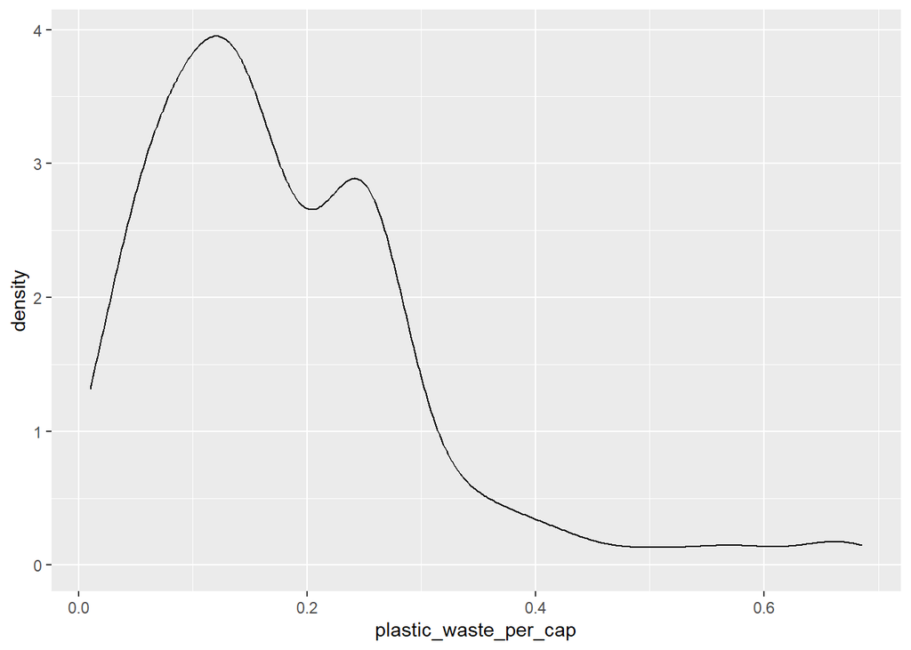

```r
ggplot(plastic_waste, aes(x = plastic_waste_per_cap)) +
      geom_density(adjust = 1)
```

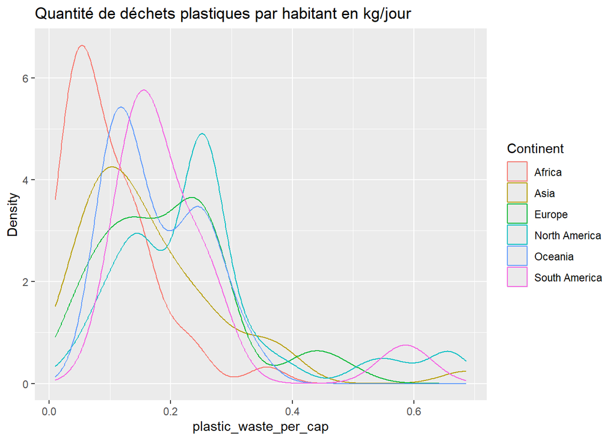

```r
ggplot(plastic_waste, aes(x = plastic_waste_per_cap, color = continent)) +
  geom_density(adjust = 1, alpha = 0.5) +
  labs(
    x = "plastic_waste_per_cap",
    y = "Density",
    title = "Quantité de déchets plastiques par habitant en kg/jour",
    color = "Continent")
```

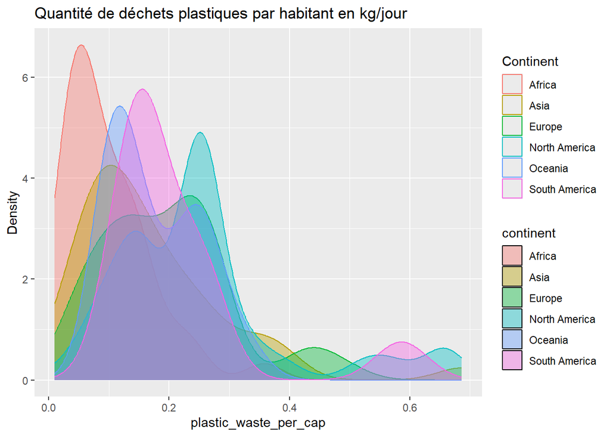

```r
ggplot(plastic_waste, aes(x = plastic_waste_per_cap,
                          fill = continent,
                          color = continent)) +
  geom_density(adjust = 1,
               alpha = 0.4) +
  labs(
    x = "plastic_waste_per_cap",
    y = "Density",
    title = "Quantité de déchets plastiques par habitant en kg/jour",
    fill = "continent",
    color = "Continent")
```

QUESTION 2: color & fill, Ce trouve dans aes car ces actions sont liées au dataset.alpha, Ce trouve dans geom_density car cela controle le graphique en un ensemble, peut importe les valeurs.

### Exercise 3

Boxplot:

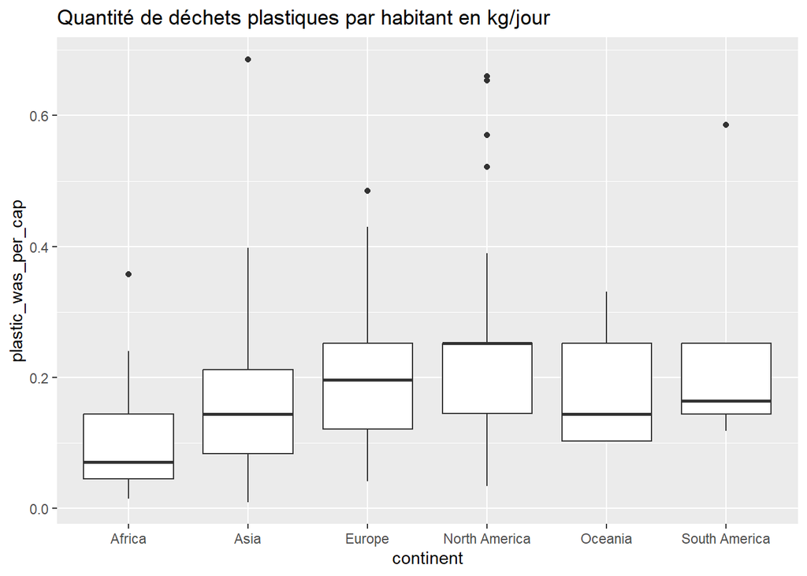

```r
ggplot(plastic_waste, aes(x = continent,
                          y = plastic_waste_per_cap)) +
  geom_boxplot() +
  labs(x = "continent",
       y = "plastic_was_per_cap",
       title = "Quantité de déchets plastiques par habitant en kg/jour")
```

Violin plot:

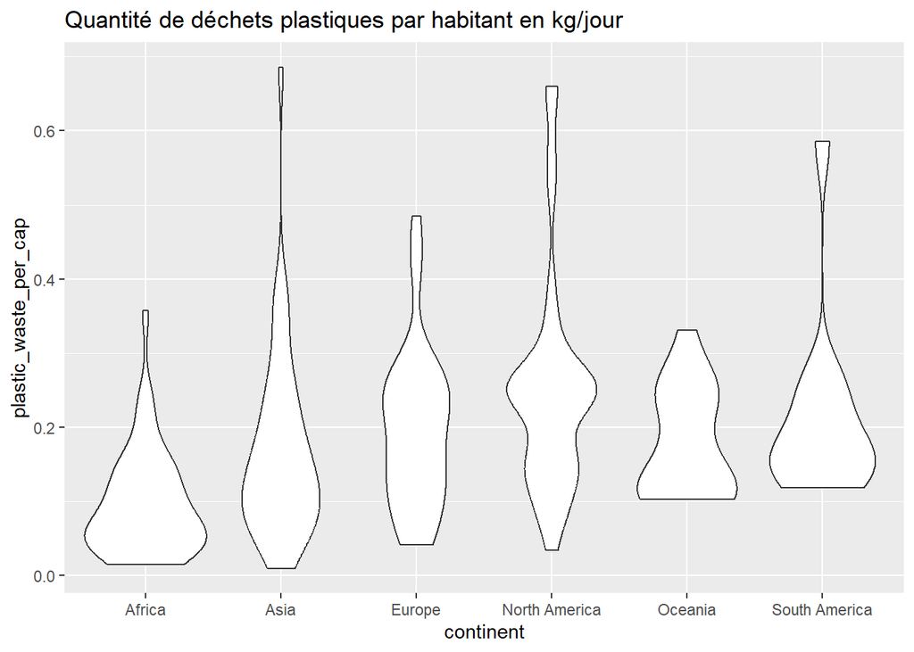

```r
ggplot(plastic_waste, aes(x = continent,
                          y = plastic_waste_per_cap)) +
  geom_violin() +
  labs(title = "Quantité de déchets plastiques par habitant en kg/jour")
```

QUESTION 3: Le violon plot permet de voir en plus de detail la distribution des données. Par exemple, l’Asie a un bas de violon plus large que le haut, ce qui signifie que la majorité de sa population on peu de dechets mais que certain en ont beaucoup. Le box plot indique unniquement qu’il y a, en Asie (parmis sa population), quelques-uns qui ont beaucoup de dechets et d’autre qui en ont peu, mais pas sa distribution.

### Exercise 4

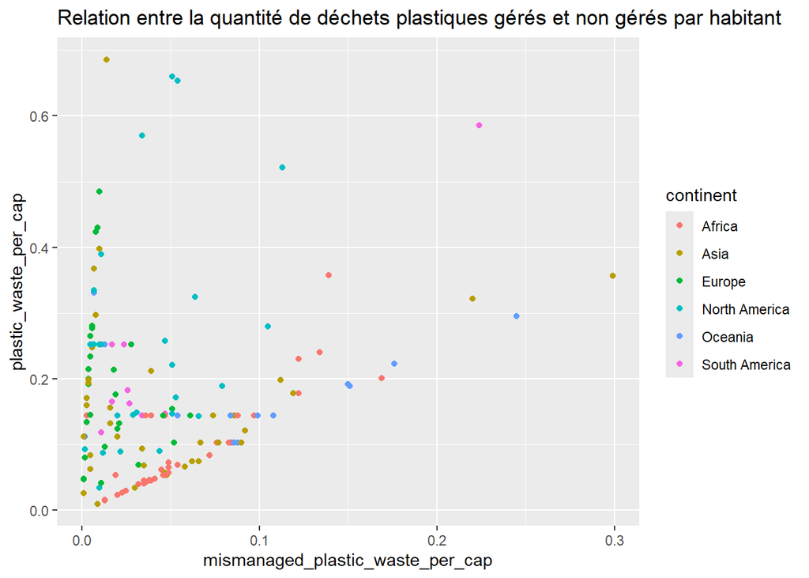

```r
ggplot(plastic_waste, aes(x = mismanaged_plastic_waste_per_cap,
                          y =plastic_waste_per_cap,
                          color = continent)) +
geom_point() +
  labs(title = "Relation entre la quantité de déchets plastiques gérés et non gérés par habitant")
```

QUESTION 4: relation, Corelation plus ou moins positive, où plus il y a de déchets plastiques, plus qu’ils seront mal gérés. Par example, lÀfrique suit bien cette relation. tendance, Par contre, la couleur permet de voir que cette relation n’est pas parfaitement linéaire. Certains pays de l’Asie produisent beacoup de déchet mais s’en occupe bien, alors que d’autres produisent peu et sont mal gérés.

### Exercise 5

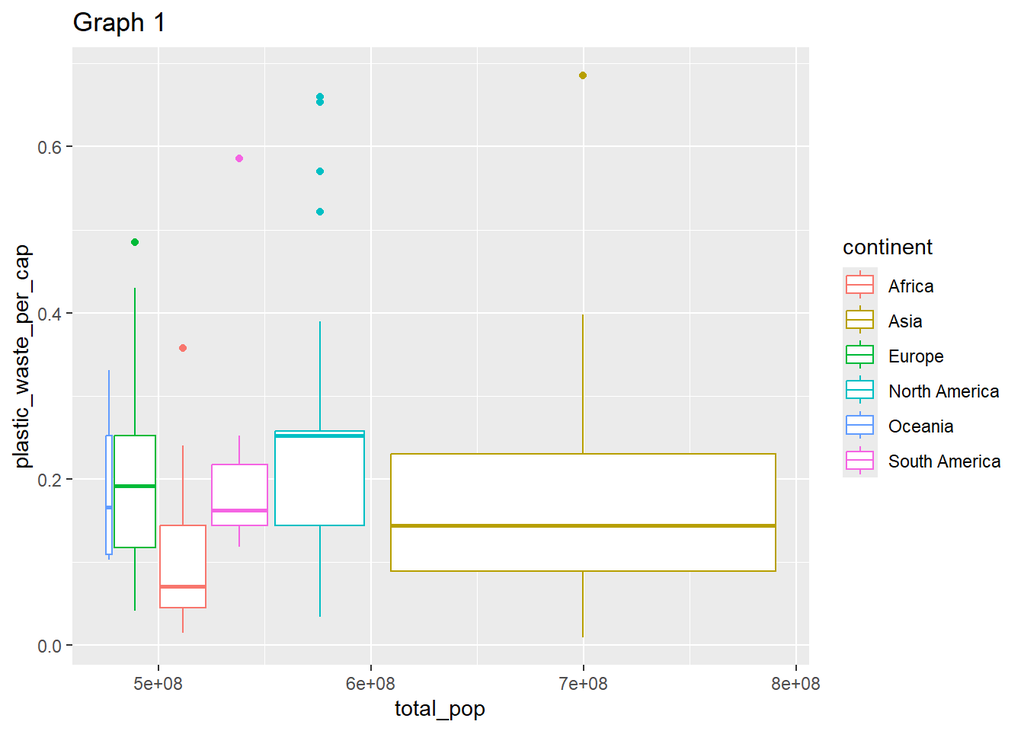

```r
ggplot(plastic_waste, aes(x = total_pop,
                          y = plastic_waste_per_cap,
                          color = continent)) +
  geom_boxplot() +
  labs(title = "Graph 1")
```

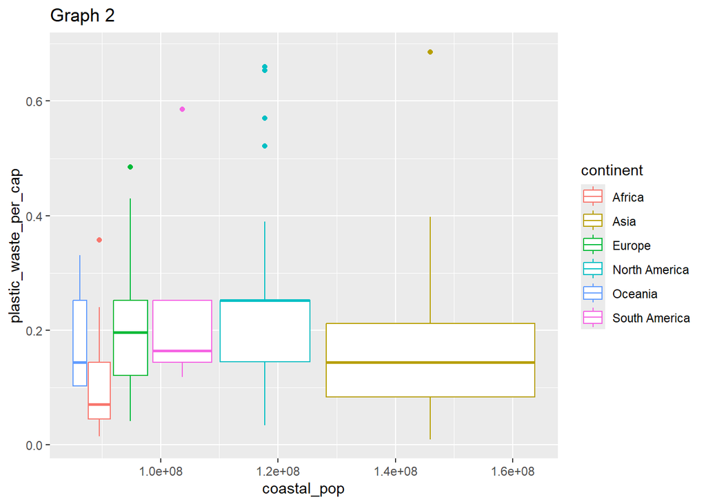

```r
ggplot(plastic_waste, aes(x = coastal_pop,
                          y = plastic_waste_per_cap,
                          color = continent)) +
  geom_boxplot()+
  labs(title = "Graph 2")
```

QUESTION 5:Il y a une relation plus forte entre la quantité de déchets plastiques par habitant et le nombre total d’habitants vivant près d’une côte. Le graph indique une petite tendance, puisque les données de Graph 2 sont plus regroupés (se disperse et varie moins) que dans graph 1.

## Conclusion

Recréez la visualisation:

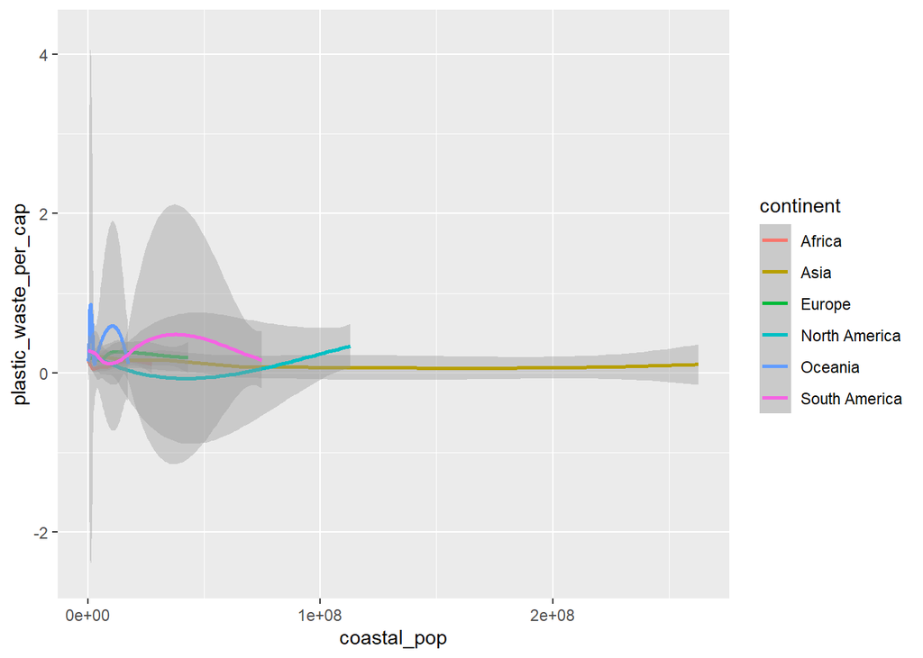

```r
ggplot(plastic_waste_coastal <- plastic_waste %>%
  mutate(coastal_pop_prop = coastal_pop / total_pop) %>%
  filter(plastic_waste_per_cap < 3),

  aes(x = coastal_pop,
      y = plastic_waste_per_cap,
      color = continent)) +
  geom_smooth()
```